[figure not shown]

**Machine Learning**  
MSE FTP MachLe  
Christoph Würsch

# Gaussian process regression (GPR) on Mauna Loa $\mathrm{CO}_2$ data.

This example is based on Section 5.4.3 of [Gaussian Processes for Machine Learning](http://www.gaussianprocess.org/gpml/chapters/RW.pdf).

The objective is to model the CO2 concentration as a function of the time $t$.

```python
%matplotlib inline
#%matplotlib notebook
import pandas as pd
import numpy as np
from matplotlib import pyplot as plt
```

The kernel is composed of several terms that are responsible for explaining different properties of the signal:

- **K1**: a long term, smooth rising trend is to be explained by an `RBF kernel`. The `RBF kernel` with a large length-scale enforces this component to be smooth; it is not enforced that the trend is rising which leaves this choice to the GP. The specific length-scale and the amplitude are free hyperparameters.
- **K2**: a seasonal component, which is to be explained by the periodic `ExpSineSquared kernel` with a fixed periodicity of 1 year. The length-scale of this periodic component, controlling its smoothness, is a free parameter. In order to allow decaying away from exact periodicity, the product with an RBF kernel is taken. The length-scale of this RBF component controls the decay time and is a further free parameter.
- **K3**: smaller, medium term irregularities are to be explained by a `RationalQuadratic` kernel component, whose length-scale and alpha parameter, which determines the diffuseness of the length-scales, are to be determined. According to [RW2006](http://gaussianprocess.org/gpml/), these irregularities can better be explained by a RationalQuadratic than an RBF kernel component, probably because it can accommodate several length-scales.
- **K4** :a "noise" term, consisting of an `RBF kernel` contribution, which shall explain the correlated noise components such as local weather phenomena, and a `WhiteKernel` contribution for the white noise. The relative amplitudes and the RBF's length scale are further free parameters.

```python
import pandas as pd
import matplotlib.pyplot as plt

# Load the CSV file
df = pd.read_csv('co2_mm_mlo.csv', parse_dates=[0])

# Assuming the first column is the date column and you want it as the DataFrame index
df.set_index(df.columns[0], inplace=True)

df.head()
```

| year | month | decimal date | average | deseasonalized | ndays | sdev | unc |
| --- | --- | --- | --- | --- | --- | --- | --- |
| 1958-01-01 | 3 | 1958.2027 | 315.70 | 314.43 | -1 | -9.99 | -0.99 |
| 1958-01-01 | 4 | 1958.2877 | 317.45 | 315.16 | -1 | -9.99 | -0.99 |
| 1958-01-01 | 5 | 1958.3699 | 317.51 | 314.71 | -1 | -9.99 | -0.99 |
| 1958-01-01 | 6 | 1958.4548 | 317.24 | 315.14 | -1 | -9.99 | -0.99 |
| 1958-01-01 | 7 | 1958.5370 | 315.86 | 315.18 | -1 | -9.99 | -0.99 |

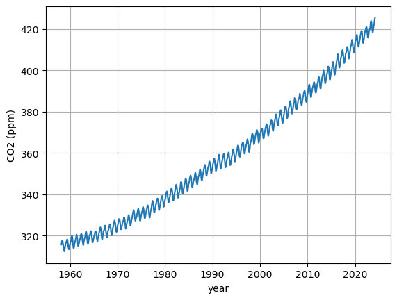

```python
X=df['decimal date'].values.reshape(-1,1)
y=df['average'].values.reshape(-1,1)

plt.plot(X,y)
plt.grid(True)
plt.xlabel('year')
plt.ylabel('CO2 (ppm)')
```

```python
from sklearn.gaussian_process import GaussianProcessRegressor
from sklearn.gaussian_process.kernels import RBF, WhiteKernel, RationalQuadratic, ExpSineSquared
```

```python
# Kernel with parameters given in GPML book
k1 = 66.0**2 * RBF(length_scale=67.0)  # long term smooth rising trend
k2 = 2.4**2 * RBF(length_scale=90.0) \
    * ExpSineSquared(length_scale=1.3, periodicity=1.0)  # seasonal component
# medium term irregularity
k3 = 0.66**2 \
    * RationalQuadratic(length_scale=1.2, alpha=0.78)
k4 = 0.18**2 * RBF(length_scale=0.134) \
    + WhiteKernel(noise_level=0.19**2)  # noise terms
kernel_gpml = k1 + k2 + k3 + k4
```

```python
gp = GaussianProcessRegressor(kernel=kernel_gpml, alpha=0,
                              optimizer=None, normalize_y=True)
gp.fit(X, y)

print("GPML kernel: %s" % gp.kernel_)
print("Log-marginal-likelihood: %.3f"
      % gp.log_marginal_likelihood(gp.kernel_.theta))
```

```
GPML kernel: 66**2 * RBF(length_scale=67) + 2.4**2 * RBF(length_scale=90) * ExpSineSquared(length_scale=1.3, periodicity=1) + 0.66**2 * RationalQuadratic(alpha=0.78, length_scale=1.2) + 0.18**2 * RBF(length_scale=0.134) + WhiteKernel(noise_level=0.0361)
Log-marginal-likelihood: 252.055
```

```python
X_ = np.linspace(X.min(), X.max() + 30, 1000)[:, np.newaxis]
y_pred, y_std = gp.predict(X_, return_std=True)
```

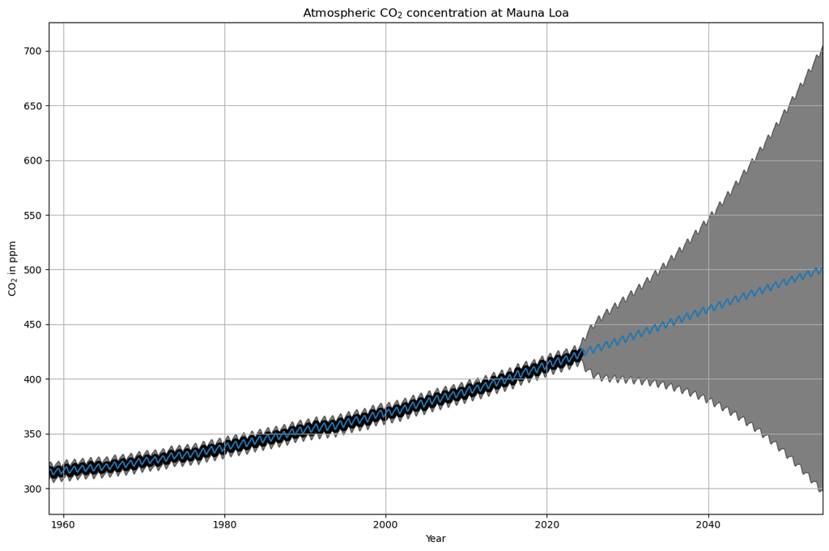

```python
# Illustration
plt.figure(figsize=(12,8))
plt.scatter(X, y, c='k')
plt.plot(X_, y_pred)
plt.fill_between(X_[:, 0], y_pred - y_std, y_pred + y_std, alpha=0.5, color='k')
plt.xlim(X_.min(), X_.max())
plt.xlabel("Year"); plt.ylabel(r"CO$_2$ in ppm")
plt.title(r"Atmospheric CO$_2$ concentration at Mauna Loa")
plt.tight_layout(); plt.grid(True); plt.show()
```

```python
# Kernel with optimized parameters
k1 = 50.0**2 * RBF(length_scale=50.0)  # long term smooth rising trend
k2 = 2.0**2 * RBF(length_scale=100.0) \
    * ExpSineSquared(length_scale=1.0, periodicity=1.0,
                     periodicity_bounds="fixed")  # seasonal component
# medium term irregularities
k3 = 0.5**2 * RationalQuadratic(length_scale=1.0, alpha=1.0)
k4 = 0.1**2 * RBF(length_scale=0.1) \
    + WhiteKernel(noise_level=0.1**2,
                  noise_level_bounds=(1e-3, np.inf))  # noise terms
kernel = k1 + k2 + k3 + k4

gp = GaussianProcessRegressor(kernel=kernel, alpha=0,
                              normalize_y=True)
gp.fit(X, y)

print("\nLearned kernel: %s" % gp.kernel_)
print("Log-marginal-likelihood: %.3f"
      % gp.log_marginal_likelihood(gp.kernel_.theta))

X_ = np.linspace(X.min(), X.max() + 30, 1000)[:, np.newaxis]
y_pred, y_std = gp.predict(X_, return_std=True)
```

```
Learned kernel: 7.94**2 * RBF(length_scale=131) + 0.223**2 * RBF(length_scale=331) * ExpSineSquared(length_scale=2.78, periodicity=1) + 0.104**2 * RationalQuadratic(alpha=4.58, length_scale=133) + 0.0245**2 * RBF(length_scale=3.22) + WhiteKernel(noise_level=0.001)
Log-marginal-likelihood: 1878.694
```

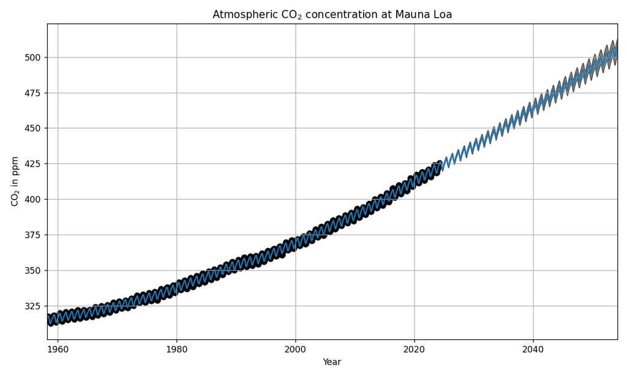

```python
%matplotlib notebook

plt.figure(figsize=(10,6))
plt.scatter(X, y, c='k')
plt.plot(X_, y_pred)
plt.fill_between(X_[:, 0], y_pred - y_std, y_pred + y_std, alpha=0.5, color='k')
plt.xlim(X_.min(), X_.max()); plt.xlabel("Year")
plt.ylabel(r"CO$_2$ in ppm"); plt.title(r"Atmospheric CO$_2$ concentration at Mauna Loa")
plt.tight_layout(); plt.grid(True); plt.show()
```